# Solomka_lab5

### Лабораторна робота №5

#### Тема: Алгоритми пошуку

#### Виконав: Студент групи КН-24-1 Соломка Борис Олегович

## Вступ

**Мета роботи:** засвоїти варіанти реалізації алгоритмів пошуку засобами Python і методи оцінювання їх складності.

**Завдання:**

- Реалізувати алгоритми лінійного та бінарного пошуку
- Оцінити їх часову складність
- Порівняти ефективність алгоритмів

## Хід роботи

### 1. Налаштування оточення

```python
import time
import random
import numpy as np
import pandas as pd
import matplotlib.pyplot as plt
%matplotlib inline
```

### 2. Реалізація алгоритмів пошуку

#### 2.1 Лінійний пошук

```python
def linear_search(a_list, x):
    i, length = 0, len(a_list)
    while i < length and x != a_list[i]:
        i += 1
    return i if i < length else -1
```

#### 2.2 Бінарний пошук

```python
def bin_search(a_list, x, left, right):
    if left > right or len(a_list) == 0:
        return -1
    middle = (left + right) // 2
    if a_list[middle] == x:
        return middle
    elif (a_list[middle] < x):
        return bin_search(a_list, x, middle + 1, right)
    else:  # a_list[middle] > x
        return bin_search(a_list, x, left, middle - 1)
```

### 3. Оцінка асимптотичної складності

#### 3.1 Лінійний пошук

Часова складність: O(n), де n - довжина списку.

Обґрунтування: у гіршому випадку (елемент відсутній або знаходиться в кінці списку) алгоритм перевірить усі n елементів списку, що дає лінійну залежність часу виконання від розміру вхідних даних.

#### 3.2 Бінарний пошук

Часова складність: O(log n), де n - довжина списку.

Обґрунтування: при кожній ітерації розмір області пошуку зменшується вдвічі. Кількість операцій, необхідних для знаходження елемента, пропорційна логарифму розміру списку, оскільки максимальна кількість ділень на 2, які можна виконати з числом n, становить log₂(n).

### 4. Експериментальне порівняння ефективності алгоритмів

```python
def linear_search_time(sizes):
    results = {'n': [], 'time': []}

    for n in sizes:
        a_list = list(range(n))
        x = -1  # Шукаємо елемент, якого немає (гірший випадок)

        start_time = time.time()
        linear_search(a_list, x)
        end_time = time.time()

        results['n'].append(n)
        results['time'].append(end_time - start_time)

    return pd.DataFrame(results)
```

```python
def binary_search_time(sizes):
    results = {'n': [], 'time': []}

    for n in sizes:
        a_list = list(range(n))
        x = -1  # Шукаємо елемент, якого немає (гірший випадок)

        start_time = time.time()
        bin_search(a_list, x, 0, len(a_list) - 1)
        end_time = time.time()

        results['n'].append(n)
        results['time'].append(end_time - start_time)

    return pd.DataFrame(results)
```

```python
sizes = [1000, 5000, 10000, 50000, 100000]
linear_df = linear_search_time(sizes)
linear_df
```

|  | n | time |
| --- | --- | --- |
| 0 | 1000 | 0.000996 |
| 1 | 5000 | 0.002308 |
| 2 | 10000 | 0.004584 |
| 3 | 50000 | 0.022712 |
| 4 | 100000 | 0.045604 |

```python
binary_df = binary_search_time(sizes)
binary_df
```

|  | n | time |
| --- | --- | --- |
| 0 | 1000 | 0.0 |
| 1 | 5000 | 0.0 |
| 2 | 10000 | 0.0 |
| 3 | 50000 | 0.0 |
| 4 | 100000 | 0.0 |

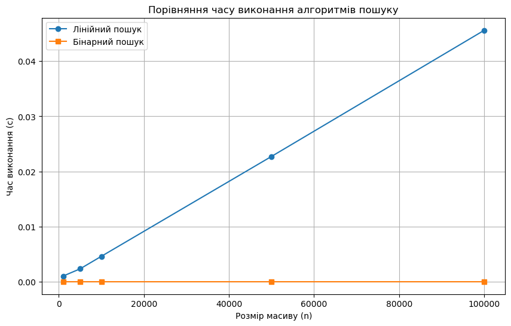

```python
plt.figure(figsize=(10, 6))
plt.plot(linear_df['n'], linear_df['time'], label='Лінійний пошук', marker='o')
plt.plot(binary_df['n'], binary_df['time'], label='Бінарний пошук', marker='s')
plt.xlabel('Розмір масиву (n)')
plt.ylabel('Час виконання (с)')
plt.title('Порівняння часу виконання алгоритмів пошуку')
plt.legend()
plt.grid(True)
plt.show()
```

## Відповіді на контрольні питання

**1. Сформулювати задачу пошуку.**

Задача пошуку полягає у знаходженні заданого елемента в наборі даних (масиві, списку, тощо) або визначенні, що елемент відсутній.

**2. Які критерії можна використовувати для оцінювання ефективності алгоритмів пошуку?**

- Часова складність (O-нотація) - кількість операцій залежно від розміру вхідних даних
- Просторова складність - обсяг пам'яті, необхідний для роботи алгоритму
- Фактичний час виконання на різних наборах даних
- Стабільність роботи на різних типах вхідних даних

**4. Що таке лінійний пошук і яка його асимптотична складність?**

Лінійний пошук - це метод послідовного перебору елементів масиву від початку до кінця, поки не буде знайдено шуканий елемент або не закінчиться масив. Асимптотична складність - O(n), де n - кількість елементів у масиві.

**5. Що таке бінарний (двійковий) пошук і в чому полягає його головний принцип роботи?**

Бінарний пошук - це алгоритм пошуку елементів у відсортованому масиві. Принцип роботи: порівняння шуканого елемента з середнім елементом масиву і відкидання половини масиву, де елемент точно не може знаходитись. Процес повторюється рекурсивно для вибраної половини, поки елемент не буде знайдено або область пошуку не стане порожньою.

**6. Які переваги і недоліки використання бінарного пошуку порівняно з лінійним?**

Переваги бінарного пошуку:

- Набагато ефективніший для великих масивів (O(log n) проти O(n))
- Швидше знаходить елементи в середньому і гіршому випадках

Недоліки бінарного пошуку:

- Працює тільки на відсортованих масивах
- Витрати на сортування можуть перевищувати виграш від бінарного пошуку при одноразовому пошуку
- Рекурсивна реалізація може призвести до переповнення стеку на дуже великих масивах

**7. Які ще алгоритми пошуку існують, окрім лінійного і бінарного?**

- Інтерполяційний пошук (покращений бінарний пошук для рівномірно розподілених даних)
- Стрибковий пошук (Jump Search)
- Експоненціальний пошук (Exponential Search)
- Хеш-пошук (O(1) в середньому випадку)
- Пошук у деревах (BST, AVL, Red-Black тощо)
- Пошук за допомогою графів

## Висновки

У ході виконання лабораторної роботи було реалізовано два алгоритми пошуку: лінійний та бінарний. На основі теоретичного аналізу та експериментальних даних було встановлено:

1. Лінійний пошук має асимптотичну складність O(n) і підходить для будь-яких масивів, відсортованих чи невідсортованих.
2. Бінарний пошук має асимптотичну складність O(log n), але вимагає попередньо відсортованого масиву.
3. Експериментальні результати підтвердили теоретичні оцінки - бінарний пошук значно ефективніший за лінійний на великих наборах даних.
4. Різниця в ефективності стає особливо помітною при розмірах масиву понад 10000 елементів, де бінарний пошук працює на порядки швидше.
5. При виборі алгоритму пошуку слід враховувати не тільки розмір даних, але й чи відсортовані дані та як часто потрібно виконувати пошук.